# DATA 603 Project - Life Expectancy

# Modelling the average life expectancy

```r
#load the data frame into memory
life = read.csv("Data/WHO_life_expectancy.csv", row.names = 1)
head(life)
```

|  | Countries | life_expectancy | traffic_mortality | prob_of_death_by_CVD_cancer_diabetes_CRD | suicide_rate | MCV2 | maternal_mortality | GGHE | alcohol_consumption | adult_obesity | dentist_density | prop_clean_fuel_reliance | doctor_density | adult_hypertension | PM | NTD | maternal_anemia | HBsAg | UHC | DTP3 | neonatal_mortality | nursing_density | under_5_mortality | TB |
| --- | --- | --- | --- | --- | --- | --- | --- | --- | --- | --- | --- | --- | --- | --- | --- | --- | --- | --- | --- | --- | --- | --- | --- | --- |
| 0 | Afghanistan | 63.2 | 15.9 | 35.3 | 4.1 | 44 | 620 | 4.3 | 0.1 | 5.5 | 0.7 | 35 | 2.5 | 40.2 | 75.2 | 14367281 | 42.6 | 0.39 | 41 | 66 | 34 | 4.5 | 56 | 189.0 |
| 1 | Albania | 78.0 | 11.7 | 11.4 | 4.3 | 92 | 8 | 9.0 | 5.1 | 21.7 | 10.3 | 84 | 18.8 | 41.8 | 16.6 | 21 | 24.8 | 0.29 | 64 | 98 | 7 | 58.3 | 9 | 17.0 |
| 2 | Algeria | 77.1 | 20.9 | 13.9 | 2.5 | 77 | 78 | 10.7 | 0.6 | 27.4 | 3.7 | 100 | 17.3 | 36.2 | 22.9 | 7081 | 33.3 | 0.08 | 74 | 91 | 16 | 15.6 | 22 | 54.0 |
| 4 | Angola | 63.1 | 26.1 | 22.2 | 6.1 | 32 | 222 | 5.4 | 6.2 | 8.2 | 0.5 | 50 | 2.1 | 38.7 | 32.3 | 8558522 | 44.5 | 4.57 | 37 | 45 | 27 | 4.0 | 69 | 325.0 |
| 5 | Antigua and Barbuda | 76.5 | 0.0 | 17.5 | 0.4 | 76 | 21 | 12.6 | 8.5 | 18.9 | 0.4 | 100 | 29.0 | 42.6 | 8.4 | 1000 | 17.2 | 0.19 | 76 | 92 | 3 | 95.8 | 6 | 4.9 |
| 6 | Argentina | 76.6 | 14.1 | 15.7 | 8.4 | 79 | 45 | 15.7 | 8.0 | 28.3 | 7.9 | 100 | 39.0 | 47.5 | 11.2 | 151847 | 11.9 | 0.01 | 79 | 76 | 5 | 54.5 | 7 | 30.0 |

```r
life = life[,-1] #remove the countries column
```

## Additive models

### Full additive model

```r
#create the first additive model
full_add_model = lm(life_expectancy~., data = life)
summary(full_add_model)
```

```
##
## Call:
## lm(formula = life_expectancy ~ ., data = life)
##
## Residuals:
##     Min      1Q  Median      3Q     Max
## -3.9994 -0.7528  0.0158  0.8522  4.6433
##
## Coefficients:
##                                            Estimate Std. Error t value Pr(>|t|)
## (Intercept)                               8.396e+01  2.137e+00  39.285  < 2e-16
## traffic_mortality                        -8.581e-02  1.689e-02  -5.081 1.25e-06
## prob_of_death_by_CVD_cancer_diabetes_CRD -3.389e-01  3.314e-02 -10.226  < 2e-16
## suicide_rate                             -5.823e-02  1.942e-02  -2.998  0.00324
## MCV2                                      8.054e-04  9.147e-03   0.088  0.92997
## maternal_mortality                       -3.426e-03  1.455e-03  -2.354  0.02003
## GGHE                                     -1.053e-03  3.923e-02  -0.027  0.97863
## alcohol_consumption                      -4.113e-02  4.087e-02  -1.006  0.31610
## adult_obesity                             1.095e-03  1.783e-02   0.061  0.95111
## dentist_density                           6.577e-02  5.705e-02   1.153  0.25104
## prop_clean_fuel_reliance                  5.990e-03  7.748e-03   0.773  0.44081
## doctor_density                            1.993e-02  1.545e-02   1.290  0.19939
## adult_hypertension                       -6.271e-02  2.133e-02  -2.941  0.00386
## PM                                        7.554e-03  1.018e-02   0.742  0.45943
## NTD                                       1.791e-10  2.234e-09   0.080  0.93623
## maternal_anemia                           1.717e-03  1.850e-02   0.093  0.92619
## HBsAg                                     7.287e-02  2.183e-01   0.334  0.73900
## UHC                                       5.003e-02  2.558e-02   1.956  0.05256
## DTP3                                     -1.877e-02  1.370e-02  -1.371  0.17272
## neonatal_mortality                       -1.182e-02  4.711e-02  -0.251  0.80233
## nursing_density                           2.097e-03  4.436e-03   0.473  0.63720
## under_5_mortality                        -8.448e-02  1.966e-02  -4.297 3.31e-05
## TB                                       -4.184e-03  1.248e-03  -3.351  0.00105
##
## (Intercept)                              ***
## traffic_mortality                        ***
## prob_of_death_by_CVD_cancer_diabetes_CRD ***
## suicide_rate                             **
## MCV2
## maternal_mortality                       *
```

[output cut: 9 more lines]

```
## maternal_anemia
## HBsAg
## UHC                                      .
## DTP3
## neonatal_mortality
## nursing_density
## under_5_mortality                        ***
## TB                                       **
## ---
## Signif. codes:  0 '***' 0.001 '**' 0.01 '*' 0.05 '.' 0.1 ' ' 1
##
## Residual standard error: 1.407 on 133 degrees of freedom
##   (27 observations deleted due to missingness)
## Multiple R-squared:  0.9635, Adjusted R-squared:  0.9575
## F-statistic: 159.6 on 22 and 133 DF,  p-value: < 2.2e-16
```

### Stepwise model selection

```r
step_model = ols_step_both_p(full_add_model, pent=0.1, prem=0.3, details=FALSE)
summary(step_model$model)
```

```
##
## Call:
## lm(formula = paste(response, "~", paste(preds, collapse = " + ")),
##     data = l)
##
## Residuals:
##     Min      1Q  Median      3Q     Max
## -4.0370 -0.6417  0.0178  0.8481  4.4442
##
## Coefficients:
##                                           Estimate Std. Error t value Pr(>|t|)
## (Intercept)                              83.432466   1.635382  51.017  < 2e-16
## UHC                                       0.062633   0.017498   3.579 0.000454
## prob_of_death_by_CVD_cancer_diabetes_CRD -0.335318   0.024526 -13.672  < 2e-16
## under_5_mortality                        -0.084609   0.009959  -8.495 1.18e-14
## traffic_mortality                        -0.088028   0.013558  -6.493 9.71e-10
## TB                                       -0.004388   0.000972  -4.514 1.21e-05
## suicide_rate                             -0.061099   0.016555  -3.691 0.000305
## adult_hypertension                       -0.060079   0.017200  -3.493 0.000615
## dentist_density                           0.063274   0.046158   1.371 0.172319
## maternal_mortality                       -0.003625   0.001181  -3.069 0.002517
## HBsAg                                     0.146244   0.130264   1.123 0.263226
## DTP3                                     -0.016140   0.008766  -1.841 0.067411
## doctor_density                            0.026699   0.012796   2.087 0.038487
## alcohol_consumption                      -0.054083   0.031482  -1.718 0.087710
##
## (Intercept)                              ***
## UHC                                      ***
## prob_of_death_by_CVD_cancer_diabetes_CRD ***
## under_5_mortality                        ***
## traffic_mortality                        ***
## TB                                       ***
## suicide_rate                             ***
## adult_hypertension                       ***
## dentist_density
## maternal_mortality                       **
## HBsAg
## DTP3                                     .
## doctor_density                           *
## alcohol_consumption                      .
## ---
## Signif. codes:  0 '***' 0.001 '**' 0.01 '*' 0.05 '.' 0.1 ' ' 1
##
## Residual standard error: 1.318 on 163 degrees of freedom
##   (6 observations deleted due to missingness)
## Multiple R-squared:  0.9674, Adjusted R-squared:  0.9648
## F-statistic:   372 on 13 and 163 DF,  p-value: < 2.2e-16
```

### Forward model selection

```r
forward_model = ols_step_forward_p(full_add_model, pent=0.1, prem=0.3, data=life)
summary(forward_model$model)
```

```
##
## Call:
## lm(formula = paste(response, "~", paste(preds, collapse = " + ")),
##     data = l)
##
## Residuals:
##     Min      1Q  Median      3Q     Max
## -4.0370 -0.6417  0.0178  0.8481  4.4442
##
## Coefficients:
##                                           Estimate Std. Error t value Pr(>|t|)
## (Intercept)                              83.432466   1.635382  51.017  < 2e-16
## UHC                                       0.062633   0.017498   3.579 0.000454
## prob_of_death_by_CVD_cancer_diabetes_CRD -0.335318   0.024526 -13.672  < 2e-16
## under_5_mortality                        -0.084609   0.009959  -8.495 1.18e-14
## traffic_mortality                        -0.088028   0.013558  -6.493 9.71e-10
## TB                                       -0.004388   0.000972  -4.514 1.21e-05
## suicide_rate                             -0.061099   0.016555  -3.691 0.000305
## adult_hypertension                       -0.060079   0.017200  -3.493 0.000615
## dentist_density                           0.063274   0.046158   1.371 0.172319
## maternal_mortality                       -0.003625   0.001181  -3.069 0.002517
## HBsAg                                     0.146244   0.130264   1.123 0.263226
## DTP3                                     -0.016140   0.008766  -1.841 0.067411
## doctor_density                            0.026699   0.012796   2.087 0.038487
## alcohol_consumption                      -0.054083   0.031482  -1.718 0.087710
##
## (Intercept)                              ***
## UHC                                      ***
## prob_of_death_by_CVD_cancer_diabetes_CRD ***
## under_5_mortality                        ***
## traffic_mortality                        ***
## TB                                       ***
## suicide_rate                             ***
## adult_hypertension                       ***
## dentist_density
## maternal_mortality                       **
## HBsAg
## DTP3                                     .
## doctor_density                           *
## alcohol_consumption                      .
## ---
## Signif. codes:  0 '***' 0.001 '**' 0.01 '*' 0.05 '.' 0.1 ' ' 1
##
## Residual standard error: 1.318 on 163 degrees of freedom
##   (6 observations deleted due to missingness)
## Multiple R-squared:  0.9674, Adjusted R-squared:  0.9648
## F-statistic:   372 on 13 and 163 DF,  p-value: < 2.2e-16
```

### Backward model selection

```r
backward_model = ols_step_backward_p(full_add_model, prem=0.3, data=life)
summary(backward_model$model)
```

```
##
## Call:
## lm(formula = paste(response, "~", paste(preds, collapse = " + ")),
##     data = l)
##
## Residuals:
##     Min      1Q  Median      3Q     Max
## -4.0370 -0.6417  0.0178  0.8481  4.4442
##
## Coefficients:
##                                           Estimate Std. Error t value Pr(>|t|)
## (Intercept)                              83.432466   1.635382  51.017  < 2e-16
## traffic_mortality                        -0.088028   0.013558  -6.493 9.71e-10
## prob_of_death_by_CVD_cancer_diabetes_CRD -0.335318   0.024526 -13.672  < 2e-16
## suicide_rate                             -0.061099   0.016555  -3.691 0.000305
## maternal_mortality                       -0.003625   0.001181  -3.069 0.002517
## alcohol_consumption                      -0.054083   0.031482  -1.718 0.087710
## dentist_density                           0.063274   0.046158   1.371 0.172319
## doctor_density                            0.026699   0.012796   2.087 0.038487
## adult_hypertension                       -0.060079   0.017200  -3.493 0.000615
## HBsAg                                     0.146244   0.130264   1.123 0.263226
## UHC                                       0.062633   0.017498   3.579 0.000454
## DTP3                                     -0.016140   0.008766  -1.841 0.067411
## under_5_mortality                        -0.084609   0.009959  -8.495 1.18e-14
## TB                                       -0.004388   0.000972  -4.514 1.21e-05
##
## (Intercept)                              ***
## traffic_mortality                        ***
## prob_of_death_by_CVD_cancer_diabetes_CRD ***
## suicide_rate                             ***
## maternal_mortality                       **
## alcohol_consumption                      .
## dentist_density
## doctor_density                           *
## adult_hypertension                       ***
## HBsAg
## UHC                                      ***
## DTP3                                     .
## under_5_mortality                        ***
## TB                                       ***
## ---
## Signif. codes:  0 '***' 0.001 '**' 0.01 '*' 0.05 '.' 0.1 ' ' 1
##
## Residual standard error: 1.318 on 163 degrees of freedom
##   (6 observations deleted due to missingness)
## Multiple R-squared:  0.9674, Adjusted R-squared:  0.9648
## F-statistic:   372 on 13 and 163 DF,  p-value: < 2.2e-16
```

### First reduced additive model

Removed all non-significant variables from the full additive model but kept *doctor_density* as the stepwise, forward, and backward model selection procedures resulted in this variable being significant. Additionally, it logically makes sense that this variable should explain a significant amount of variance in *life_expectancy*.

```r
reduced_add_m1 = lm(life_expectancy ~
                    traffic_mortality +
                    prob_of_death_by_CVD_cancer_diabetes_CRD +
                    suicide_rate +
                    maternal_mortality +
                    adult_hypertension +
                    UHC +
                    under_5_mortality +
                    TB +
                    doctor_density,
                    data=life)
summary(reduced_add_m1)
```

```
##
## Call:
## lm(formula = life_expectancy ~ traffic_mortality + prob_of_death_by_CVD_cancer_diabetes_CRD +
##     suicide_rate + maternal_mortality + adult_hypertension +
##     UHC + under_5_mortality + TB + doctor_density, data = life)
##
## Residuals:
##     Min      1Q  Median      3Q     Max
## -3.9184 -0.8118 -0.0252  0.8961  4.1996
##
## Coefficients:
##                                            Estimate Std. Error t value Pr(>|t|)
## (Intercept)                              82.1277934  1.4818757  55.422  < 2e-16
## traffic_mortality                        -0.0871481  0.0134777  -6.466 1.00e-09
## prob_of_death_by_CVD_cancer_diabetes_CRD -0.3356871  0.0232356 -14.447  < 2e-16
## suicide_rate                             -0.0729776  0.0158120  -4.615 7.65e-06
## maternal_mortality                       -0.0020793  0.0010143  -2.050 0.041891
## adult_hypertension                       -0.0557541  0.0168828  -3.302 0.001166
## UHC                                       0.0572774  0.0174879   3.275 0.001277
## under_5_mortality                        -0.0871696  0.0093591  -9.314  < 2e-16
## TB                                       -0.0042506  0.0009421  -4.512 1.19e-05
## doctor_density                            0.0342045  0.0098034   3.489 0.000616
##
## (Intercept)                              ***
## traffic_mortality                        ***
## prob_of_death_by_CVD_cancer_diabetes_CRD ***
## suicide_rate                             ***
## maternal_mortality                       *
## adult_hypertension                       **
## UHC                                      **
## under_5_mortality                        ***
## TB                                       ***
## doctor_density                           ***
## ---
## Signif. codes:  0 '***' 0.001 '**' 0.01 '*' 0.05 '.' 0.1 ' ' 1
##
## Residual standard error: 1.352 on 172 degrees of freedom
##   (1 observation deleted due to missingness)
## Multiple R-squared:  0.966,  Adjusted R-squared:  0.9642
## F-statistic: 542.8 on 9 and 172 DF,  p-value: < 2.2e-16
```

Therefore, we will continue with the reduced additive model (*reduced_add_m1*).

## Interaction models

### Full interaction model

```r
full_interaction_model = lm(life_expectancy ~
                           (traffic_mortality +
                            prob_of_death_by_CVD_cancer_diabetes_CRD +
                            suicide_rate +
                            maternal_mortality +
                            adult_hypertension +
                            UHC +
                            under_5_mortality +
                            TB +
                            doctor_density)^2,
                            data = life)
summary(full_interaction_model)
```

```
##
## Call:
## lm(formula = life_expectancy ~ (traffic_mortality + prob_of_death_by_CVD_cancer_diabetes_CRD +
##     suicide_rate + maternal_mortality + adult_hypertension +
##     UHC + under_5_mortality + TB + doctor_density)^2, data = life)
##
## Residuals:
##     Min      1Q  Median      3Q     Max
## -4.0272 -0.5878 -0.0315  0.6814  2.1832
##
## Coefficients:
##                                                               Estimate
## (Intercept)                                                  8.103e+01
## traffic_mortality                                           -1.813e-01
## prob_of_death_by_CVD_cancer_diabetes_CRD                    -1.591e-01
## suicide_rate                                                -5.965e-01
## maternal_mortality                                          -3.302e-03
## adult_hypertension                                          -3.420e-02
## UHC                                                          1.093e-01
## under_5_mortality                                           -1.886e-01
## TB                                                           1.699e-02
## doctor_density                                               1.718e-01
## traffic_mortality:prob_of_death_by_CVD_cancer_diabetes_CRD   2.582e-03
## traffic_mortality:suicide_rate                              -6.521e-03
## traffic_mortality:maternal_mortality                        -9.898e-05
## traffic_mortality:adult_hypertension                        -2.929e-04
## traffic_mortality:UHC                                        2.096e-03
## traffic_mortality:under_5_mortality                          2.286e-03
## traffic_mortality:TB                                        -3.986e-04
## traffic_mortality:doctor_density                            -7.397e-04
## prob_of_death_by_CVD_cancer_diabetes_CRD:suicide_rate        2.549e-03
## prob_of_death_by_CVD_cancer_diabetes_CRD:maternal_mortality -2.415e-04
## prob_of_death_by_CVD_cancer_diabetes_CRD:adult_hypertension  2.501e-03
## prob_of_death_by_CVD_cancer_diabetes_CRD:UHC                -4.266e-03
## prob_of_death_by_CVD_cancer_diabetes_CRD:under_5_mortality   7.138e-04
## prob_of_death_by_CVD_cancer_diabetes_CRD:TB                 -9.979e-05
## prob_of_death_by_CVD_cancer_diabetes_CRD:doctor_density     -2.983e-03
## suicide_rate:maternal_mortality                              5.339e-04
## suicide_rate:adult_hypertension                              3.718e-03
## suicide_rate:UHC                                             6.908e-03
```

[output cut: 104 more lines]

```
## adult_hypertension:TB                                        0.14377
## adult_hypertension:doctor_density                            0.45389
## UHC:under_5_mortality                                        0.87217
## UHC:TB                                                       0.70287
## UHC:doctor_density                                           0.35346
## under_5_mortality:TB                                         0.15391
## under_5_mortality:doctor_density                             0.69799
## TB:doctor_density                                            0.24906
## ---
## Signif. codes:  0 '***' 0.001 '**' 0.01 '*' 0.05 '.' 0.1 ' ' 1
##
## Residual standard error: 1.042 on 136 degrees of freedom
##   (1 observation deleted due to missingness)
## Multiple R-squared:  0.984,  Adjusted R-squared:  0.9787
## F-statistic: 186.2 on 45 and 136 DF,  p-value: < 2.2e-16
```

### Reduced interaction model

Removed non-significant interactions from the full interaction model.

```r
reduced_interaction_m1 = lm(life_expectancy ~
                            traffic_mortality +
                            prob_of_death_by_CVD_cancer_diabetes_CRD +
                            suicide_rate +
                            maternal_mortality +
                            adult_hypertension +
                            UHC +
                            under_5_mortality +
                            TB +
                            doctor_density +
                            traffic_mortality * suicide_rate +
                            traffic_mortality * TB +
                            suicide_rate * maternal_mortality +
                            suicide_rate * UHC +
                            maternal_mortality * TB,
                            data = life)
summary(reduced_interaction_m1)
```

```
##
## Call:
## lm(formula = life_expectancy ~ traffic_mortality + prob_of_death_by_CVD_cancer_diabetes_CRD +
##     suicide_rate + maternal_mortality + adult_hypertension +
##     UHC + under_5_mortality + TB + doctor_density + traffic_mortality *
##     suicide_rate + traffic_mortality * TB + suicide_rate * maternal_mortality +
##     suicide_rate * UHC + maternal_mortality * TB, data = life)
##
## Residuals:
##     Min      1Q  Median      3Q     Max
## -3.9803 -0.7319 -0.1049  0.8015  2.6610
##
## Coefficients:
##                                            Estimate Std. Error t value Pr(>|t|)
## (Intercept)                               8.183e+01  1.520e+00  53.841  < 2e-16
## traffic_mortality                         8.042e-03  1.976e-02   0.407 0.684593
## prob_of_death_by_CVD_cancer_diabetes_CRD -3.387e-01  2.365e-02 -14.321  < 2e-16
## suicide_rate                             -1.781e-01  1.052e-01  -1.693 0.092384
## maternal_mortality                       -6.678e-03  1.481e-03  -4.508 1.23e-05
## adult_hypertension                       -5.493e-02  1.537e-02  -3.574 0.000460
## UHC                                       4.351e-02  1.831e-02   2.377 0.018601
## under_5_mortality                        -8.273e-02  8.478e-03  -9.758  < 2e-16
## TB                                        2.197e-03  1.893e-03   1.161 0.247483
## doctor_density                            3.074e-02  9.121e-03   3.371 0.000932
## traffic_mortality:suicide_rate           -6.122e-03  1.988e-03  -3.079 0.002427
## traffic_mortality:TB                     -4.338e-04  1.015e-04  -4.274 3.23e-05
## suicide_rate:maternal_mortality           2.497e-04  1.156e-04   2.160 0.032191
## suicide_rate:UHC                          2.687e-03  1.419e-03   1.894 0.059976
## maternal_mortality:TB                     1.659e-05  5.381e-06   3.084 0.002391
##
## (Intercept)                              ***
## traffic_mortality
## prob_of_death_by_CVD_cancer_diabetes_CRD ***
## suicide_rate                             .
## maternal_mortality                       ***
## adult_hypertension                       ***
## UHC                                      *
## under_5_mortality                        ***
## TB
## doctor_density                           ***
## traffic_mortality:suicide_rate           **
## traffic_mortality:TB                     ***
## suicide_rate:maternal_mortality          *
## suicide_rate:UHC                         .
## maternal_mortality:TB                    **
## ---
## Signif. codes:  0 '***' 0.001 '**' 0.01 '*' 0.05 '.' 0.1 ' ' 1
##
## Residual standard error: 1.214 on 167 degrees of freedom
##   (1 observation deleted due to missingness)
## Multiple R-squared:  0.9734, Adjusted R-squared:  0.9711
## F-statistic:   436 on 14 and 167 DF,  p-value: < 2.2e-16
```

## Polynomial models

### Variable visualizations

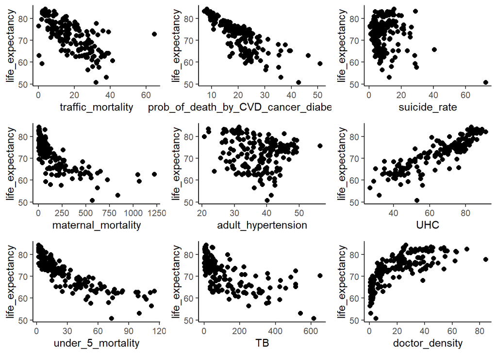

```r
#define variables
y_var = "life_expectancy"
x_var = c("traffic_mortality","prob_of_death_by_CVD_cancer_diabetes_CRD","suicide_rate","maternal_mortality","adult_hypertension","UHC","under_5_mortality","TB","doctor_density")

#create plots
plots = list()
for(i in 1:length(x_var)){
  plot = ggplot(data = life, aes_string(y = y_var, x = x_var[i])) +
    geom_point(size = 2) +
    theme_classic()

  plots[[i]] = plot
}
#visualize plots
grid.arrange(grobs = plots, ncol = 3)
```

From these plots, *maternal_mortality*, *under_5_mortality*, *doctor_density* appear non-linear. We will add second order parameters for these variables.

### Full polynomial model

```r
full_poly_model = lm(life_expectancy ~
                     traffic_mortality +
                     prob_of_death_by_CVD_cancer_diabetes_CRD +
                     suicide_rate +
                     maternal_mortality +
                     I(maternal_mortality^2) +
                     adult_hypertension +
                     UHC +
                     under_5_mortality +
                     I(under_5_mortality^2) +
                     TB +
                     doctor_density +
                     I(doctor_density^2) +
                     traffic_mortality * suicide_rate +
                     traffic_mortality * TB +
                     suicide_rate * maternal_mortality +
                     suicide_rate * UHC +
                     maternal_mortality * TB,
                     data = life)
summary(full_poly_model)
```

```
##
## Call:
## lm(formula = life_expectancy ~ traffic_mortality + prob_of_death_by_CVD_cancer_diabetes_CRD +
##     suicide_rate + maternal_mortality + I(maternal_mortality^2) +
##     adult_hypertension + UHC + under_5_mortality + I(under_5_mortality^2) +
##     TB + doctor_density + I(doctor_density^2) + traffic_mortality *
##     suicide_rate + traffic_mortality * TB + suicide_rate * maternal_mortality +
##     suicide_rate * UHC + maternal_mortality * TB, data = life)
##
## Residuals:
##     Min      1Q  Median      3Q     Max
## -3.9620 -0.7032 -0.0020  0.7218  2.6957
##
## Coefficients:
##                                            Estimate Std. Error t value Pr(>|t|)
## (Intercept)                               8.455e+01  1.547e+00  54.645  < 2e-16
## traffic_mortality                         2.966e-02  1.905e-02   1.557 0.121333
## prob_of_death_by_CVD_cancer_diabetes_CRD -3.227e-01  2.273e-02 -14.200  < 2e-16
## suicide_rate                             -2.392e-01  1.001e-01  -2.388 0.018063
## maternal_mortality                       -1.007e-02  2.350e-03  -4.286 3.10e-05
## I(maternal_mortality^2)                   3.270e-06  1.761e-06   1.857 0.065148
## adult_hypertension                       -6.873e-02  1.478e-02  -4.651 6.78e-06
## UHC                                       9.360e-03  1.872e-02   0.500 0.617803
## under_5_mortality                        -1.340e-01  2.116e-02  -6.333 2.22e-09
## I(under_5_mortality^2)                    4.593e-04  1.648e-04   2.787 0.005952
## TB                                        3.011e-03  1.822e-03   1.652 0.100464
## doctor_density                            7.064e-02  2.508e-02   2.817 0.005447
## I(doctor_density^2)                      -6.614e-04  3.141e-04  -2.106 0.036745
## traffic_mortality:suicide_rate           -6.814e-03  1.892e-03  -3.601 0.000420
## traffic_mortality:TB                     -3.682e-04  9.815e-05  -3.751 0.000244
## suicide_rate:maternal_mortality           3.566e-04  1.139e-04   3.132 0.002056
## suicide_rate:UHC                          3.507e-03  1.353e-03   2.592 0.010391
## maternal_mortality:TB                     8.700e-06  5.371e-06   1.620 0.107179
##
## (Intercept)                              ***
## traffic_mortality
## prob_of_death_by_CVD_cancer_diabetes_CRD ***
## suicide_rate                             *
## maternal_mortality                       ***
## I(maternal_mortality^2)                  .
## adult_hypertension                       ***
## UHC
## under_5_mortality                        ***
## I(under_5_mortality^2)                   **
## TB
## doctor_density                           **
## I(doctor_density^2)                      *
## traffic_mortality:suicide_rate           ***
## traffic_mortality:TB                     ***
## suicide_rate:maternal_mortality          **
## suicide_rate:UHC                         *
## maternal_mortality:TB
## ---
## Signif. codes:  0 '***' 0.001 '**' 0.01 '*' 0.05 '.' 0.1 ' ' 1
##
## Residual standard error: 1.138 on 164 degrees of freedom
##   (1 observation deleted due to missingness)
## Multiple R-squared:  0.977,  Adjusted R-squared:  0.9746
## F-statistic: 410.1 on 17 and 164 DF,  p-value: < 2.2e-16
```

### First reduced polynomial model

Removed the non-significant interaction paramter between *maternal_mortality* and *TB*.

```r
reduced_poly_m1 = lm(life_expectancy ~
                     traffic_mortality +
                     prob_of_death_by_CVD_cancer_diabetes_CRD +
                     suicide_rate +
                     maternal_mortality +
                     I(maternal_mortality^2) +
                     adult_hypertension +
                     UHC +
                     under_5_mortality +
                     I(under_5_mortality^2) +
                     TB +
                     doctor_density +
                     I(doctor_density^2) +
                     traffic_mortality * suicide_rate +
                     traffic_mortality * TB +
                     suicide_rate * maternal_mortality +
                     suicide_rate * UHC,
                     data = life)
summary(reduced_poly_m1)
```

```
##
## Call:
## lm(formula = life_expectancy ~ traffic_mortality + prob_of_death_by_CVD_cancer_diabetes_CRD +
##     suicide_rate + maternal_mortality + I(maternal_mortality^2) +
##     adult_hypertension + UHC + under_5_mortality + I(under_5_mortality^2) +
##     TB + doctor_density + I(doctor_density^2) + traffic_mortality *
##     suicide_rate + traffic_mortality * TB + suicide_rate * maternal_mortality +
##     suicide_rate * UHC, data = life)
##
## Residuals:
##     Min      1Q  Median      3Q     Max
## -3.8807 -0.7566 -0.0228  0.7630  2.6590
##
## Coefficients:
##                                            Estimate Std. Error t value Pr(>|t|)
## (Intercept)                               8.447e+01  1.554e+00  54.355  < 2e-16
## traffic_mortality                         2.740e-02  1.909e-02   1.435  0.15318
## prob_of_death_by_CVD_cancer_diabetes_CRD -3.163e-01  2.249e-02 -14.064  < 2e-16
## suicide_rate                             -2.612e-01  9.969e-02  -2.620  0.00961
## maternal_mortality                       -9.596e-03  2.343e-03  -4.096 6.58e-05
## I(maternal_mortality^2)                   4.034e-06  1.705e-06   2.366  0.01915
## adult_hypertension                       -6.714e-02  1.482e-02  -4.531 1.12e-05
## UHC                                       9.113e-03  1.881e-02   0.484  0.62878
## under_5_mortality                        -1.386e-01  2.107e-02  -6.577 6.04e-10
## I(under_5_mortality^2)                    4.891e-04  1.646e-04   2.972  0.00340
## TB                                        2.676e-03  1.820e-03   1.471  0.14324
## doctor_density                            7.005e-02  2.520e-02   2.780  0.00607
## I(doctor_density^2)                      -6.646e-04  3.156e-04  -2.106  0.03675
## traffic_mortality:suicide_rate           -7.849e-03  1.790e-03  -4.385 2.06e-05
## traffic_mortality:TB                     -2.685e-04  7.685e-05  -3.494  0.00061
## suicide_rate:maternal_mortality           4.424e-04  1.013e-04   4.368 2.20e-05
## suicide_rate:UHC                          3.860e-03  1.342e-03   2.877  0.00454
##
## (Intercept)                              ***
## traffic_mortality
## prob_of_death_by_CVD_cancer_diabetes_CRD ***
## suicide_rate                             **
## maternal_mortality                       ***
## I(maternal_mortality^2)                  *
## adult_hypertension                       ***
## UHC
## under_5_mortality                        ***
## I(under_5_mortality^2)                   **
## TB
## doctor_density                           **
## I(doctor_density^2)                      *
## traffic_mortality:suicide_rate           ***
## traffic_mortality:TB                     ***
## suicide_rate:maternal_mortality          ***
## suicide_rate:UHC                         **
## ---
## Signif. codes:  0 '***' 0.001 '**' 0.01 '*' 0.05 '.' 0.1 ' ' 1
##
## Residual standard error: 1.144 on 165 degrees of freedom
##   (1 observation deleted due to missingness)
## Multiple R-squared:  0.9766, Adjusted R-squared:  0.9744
## F-statistic: 431.3 on 16 and 165 DF,  p-value: < 2.2e-16
```

## Checking assumptions

### Multicollinearity

```r
#calculate VIF values using the reduced additive model
vif(reduced_add_m1)
```

```
##                        traffic_mortality
##                                 2.103839
## prob_of_death_by_CVD_cancer_diabetes_CRD
##                                 3.219099
##                             suicide_rate
##                                 1.579668
##                       maternal_mortality
##                                 4.531292
##                       adult_hypertension
##                                 1.247046
##                                      UHC
##                                 8.230149
##                        under_5_mortality
##                                 6.613750
##                                       TB
##                                 1.709273
##                           doctor_density
##                                 3.027328
```

```r
#calculate correlation between UHC and doctor_density
cor(life$UHC, life$doctor_density, use = 'complete.obs')
```

```
## [1] 0.7811349
```

```r
cor(life$under_5_mortality, life$maternal_mortality, use = 'complete.obs')
```

```
## [1] 0.8625881
```

Removed the *UHC* and *under_5_mortality* variables due to high multicollinearity with *doctor_density* and *maternal_mortality* respectively.

#### Second additive model

Additive model with the collinear terms removed (*UHC* and *under_5_mortality*).

```r
reduced_add_m2 = lm(life_expectancy ~
                    traffic_mortality +
                    prob_of_death_by_CVD_cancer_diabetes_CRD +
                    suicide_rate +
                    maternal_mortality +
                    adult_hypertension +
                    TB +
                    doctor_density,
                    data=life)
vif(reduced_add_m2)
```

```
##                        traffic_mortality
##                                 2.080726
## prob_of_death_by_CVD_cancer_diabetes_CRD
##                                 2.157153
##                             suicide_rate
##                                 1.326996
##                       maternal_mortality
##                                 1.877275
##                       adult_hypertension
##                                 1.215048
##                                       TB
##                                 1.671469
##                           doctor_density
##                                 2.607131
```

All variable VIF scores are low (below 3), therefore there are no issues with multicollinearity between independent variables.

#### Second reduced polynomial model

Polynomial/interaction model with the collinear terms removed (*UHC* and *under_5_mortality*).

```r
reduced_poly_m2 = lm(life_expectancy ~
                     traffic_mortality +
                     prob_of_death_by_CVD_cancer_diabetes_CRD +
                     suicide_rate +
                     maternal_mortality +
                     I(maternal_mortality^2) +
                     adult_hypertension +
                     TB +
                     doctor_density +
                     I(doctor_density^2) +
                     traffic_mortality * suicide_rate +
                     traffic_mortality * TB +
                     suicide_rate * maternal_mortality,
                     data = life)
summary(reduced_poly_m2)
```

```
##
## Call:
## lm(formula = life_expectancy ~ traffic_mortality + prob_of_death_by_CVD_cancer_diabetes_CRD +
##     suicide_rate + maternal_mortality + I(maternal_mortality^2) +
##     adult_hypertension + TB + doctor_density + I(doctor_density^2) +
##     traffic_mortality * suicide_rate + traffic_mortality * TB +
##     suicide_rate * maternal_mortality, data = life)
##
## Residuals:
##     Min      1Q  Median      3Q     Max
## -5.6446 -0.7607  0.1290  0.8939  5.2353
##
## Coefficients:
##                                            Estimate Std. Error t value Pr(>|t|)
## (Intercept)                               8.417e+01  9.204e-01  91.447  < 2e-16
## traffic_mortality                         1.010e-02  2.563e-02   0.394 0.694116
## prob_of_death_by_CVD_cancer_diabetes_CRD -4.099e-01  2.369e-02 -17.305  < 2e-16
## suicide_rate                              3.680e-02  3.520e-02   1.045 0.297353
## maternal_mortality                       -2.124e-02  2.538e-03  -8.370 2.09e-14
## I(maternal_mortality^2)                   9.745e-06  2.070e-06   4.707 5.20e-06
## adult_hypertension                       -6.526e-02  2.015e-02  -3.239 0.001443
## TB                                        4.674e-04  2.397e-03   0.195 0.845613
## doctor_density                            1.584e-01  3.075e-02   5.149 7.21e-07
## I(doctor_density^2)                      -1.513e-03  4.050e-04  -3.735 0.000256
## traffic_mortality:suicide_rate           -6.544e-03  2.376e-03  -2.754 0.006533
## traffic_mortality:TB                     -2.389e-04  1.035e-04  -2.307 0.022248
## suicide_rate:maternal_mortality           2.649e-04  1.077e-04   2.460 0.014892
##
## (Intercept)                              ***
## traffic_mortality
## prob_of_death_by_CVD_cancer_diabetes_CRD ***
## suicide_rate
## maternal_mortality                       ***
## I(maternal_mortality^2)                  ***
## adult_hypertension                       **
## TB
## doctor_density                           ***
## I(doctor_density^2)                      ***
## traffic_mortality:suicide_rate           **
## traffic_mortality:TB                     *
## suicide_rate:maternal_mortality          *
## ---
## Signif. codes:  0 '***' 0.001 '**' 0.01 '*' 0.05 '.' 0.1 ' ' 1
##
## Residual standard error: 1.565 on 169 degrees of freedom
##   (1 observation deleted due to missingness)
## Multiple R-squared:  0.9552, Adjusted R-squared:  0.952
## F-statistic: 300.4 on 12 and 169 DF,  p-value: < 2.2e-16
```

### Outliers

#### Cook’s distance

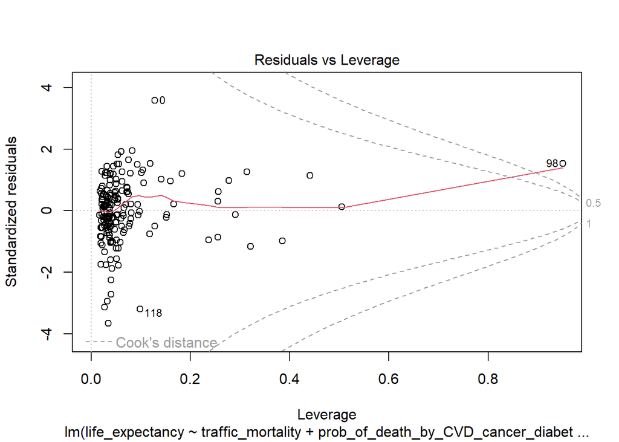

```r
#residual vs leverage plot
plot(reduced_poly_m2, which = 5)
```

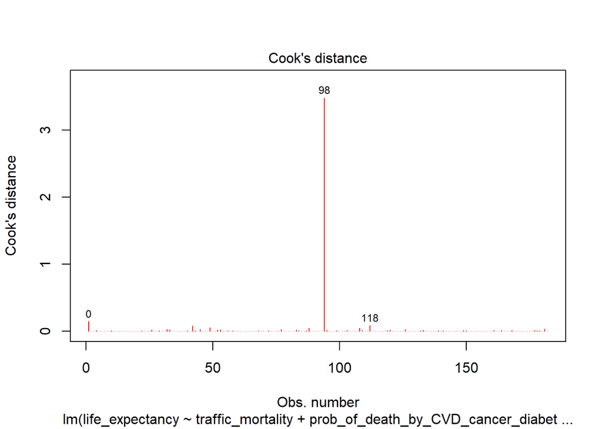

```r
#cooks distance of each point
plot(reduced_poly_m2, pch = 18, col = "red", which = c(4))
```

The 98th observation appears to be influential given it’s high leverage and Cook’s distance greater than 1. This point is likely an outlier.

#### Leverage

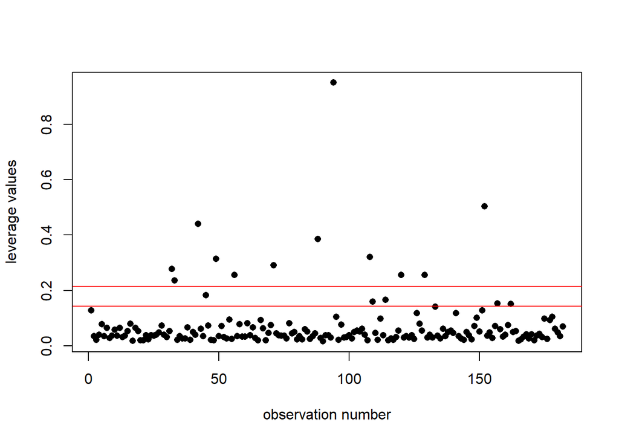

```r
#leverage of each point
lev = hatvalues(reduced_poly_m2)
p = length(coef(reduced_poly_m2))
n = length(lev)
plot(x = 1:length(lev), lev, pch = 16, xlab = "observation number", ylab = "leverage values")
abline(h = 2 * p / n, lty = 1, col = "red")
abline(h = 3 * p / n, lty = 1, col = "red")
```

There appears to be some additional influential points that may indicate outliers.

```r
#remove outlying obervations
outlier = lev > (3 * p / n)
life_outlier = life[!outlier,]
head(life_outlier)
```

|  | life_expectancy | traffic_mortality | prob_of_death_by_CVD_cancer_diabetes_CRD | suicide_rate | MCV2 | maternal_mortality | GGHE | alcohol_consumption | adult_obesity | dentist_density | prop_clean_fuel_reliance | doctor_density | adult_hypertension | PM | NTD | maternal_anemia | HBsAg | UHC | DTP3 | neonatal_mortality | nursing_density | under_5_mortality | TB |
| --- | --- | --- | --- | --- | --- | --- | --- | --- | --- | --- | --- | --- | --- | --- | --- | --- | --- | --- | --- | --- | --- | --- | --- |
| 0 | 63.2 | 15.9 | 35.3 | 4.1 | 44 | 620 | 4.3 | 0.1 | 5.5 | 0.7 | 35 | 2.5 | 40.2 | 75.2 | 14367281 | 42.6 | 0.39 | 41 | 66 | 34 | 4.5 | 56 | 189.0 |
| 1 | 78.0 | 11.7 | 11.4 | 4.3 | 92 | 8 | 9.0 | 5.1 | 21.7 | 10.3 | 84 | 18.8 | 41.8 | 16.6 | 21 | 24.8 | 0.29 | 64 | 98 | 7 | 58.3 | 9 | 17.0 |
| 2 | 77.1 | 20.9 | 13.9 | 2.5 | 77 | 78 | 10.7 | 0.6 | 27.4 | 3.7 | 100 | 17.3 | 36.2 | 22.9 | 7081 | 33.3 | 0.08 | 74 | 91 | 16 | 15.6 | 22 | 54.0 |
| 4 | 63.1 | 26.1 | 22.2 | 6.1 | 32 | 222 | 5.4 | 6.2 | 8.2 | 0.5 | 50 | 2.1 | 38.7 | 32.3 | 8558522 | 44.5 | 4.57 | 37 | 45 | 27 | 4.0 | 69 | 325.0 |
| 5 | 76.5 | 0.0 | 17.5 | 0.4 | 76 | 21 | 12.6 | 8.5 | 18.9 | 0.4 | 100 | 29.0 | 42.6 | 8.4 | 1000 | 17.2 | 0.19 | 76 | 92 | 3 | 95.8 | 6 | 4.9 |
| 6 | 76.6 | 14.1 | 15.7 | 8.4 | 79 | 45 | 15.7 | 8.0 | 28.3 | 7.9 | 100 | 39.0 | 47.5 | 11.2 | 151847 | 11.9 | 0.01 | 79 | 76 | 5 | 54.5 | 7 | 30.0 |

#### Fitting the model with outliers removed

```r
outlier_poly_m1 = lm(life_expectancy ~
                     traffic_mortality +
                     prob_of_death_by_CVD_cancer_diabetes_CRD +
                     suicide_rate +
                     maternal_mortality +
                     I(maternal_mortality^2) +
                     adult_hypertension +
                     TB +
                     doctor_density +
                     I(doctor_density^2) +
                     traffic_mortality * suicide_rate +
                     traffic_mortality * TB +
                     suicide_rate * maternal_mortality,
                     data = life_outlier)
summary(outlier_poly_m1)
```

```
##
## Call:
## lm(formula = life_expectancy ~ traffic_mortality + prob_of_death_by_CVD_cancer_diabetes_CRD +
##     suicide_rate + maternal_mortality + I(maternal_mortality^2) +
##     adult_hypertension + TB + doctor_density + I(doctor_density^2) +
##     traffic_mortality * suicide_rate + traffic_mortality * TB +
##     suicide_rate * maternal_mortality, data = life_outlier)
##
## Residuals:
##     Min      1Q  Median      3Q     Max
## -5.6616 -0.7229  0.1552  0.8959  3.6146
##
## Coefficients:
##                                            Estimate Std. Error t value Pr(>|t|)
## (Intercept)                               8.410e+01  9.976e-01  84.305  < 2e-16
## traffic_mortality                        -1.180e-02  4.062e-02  -0.291 0.771804
## prob_of_death_by_CVD_cancer_diabetes_CRD -3.866e-01  2.648e-02 -14.599  < 2e-16
## suicide_rate                              7.705e-02  5.025e-02   1.533 0.127220
## maternal_mortality                       -1.374e-02  4.266e-03  -3.221 0.001555
## I(maternal_mortality^2)                   7.875e-06  2.599e-06   3.030 0.002862
## adult_hypertension                       -7.874e-02  2.069e-02  -3.806 0.000202
## TB                                        3.543e-04  3.416e-03   0.104 0.917526
## doctor_density                            1.677e-01  3.443e-02   4.870  2.7e-06
## I(doctor_density^2)                      -1.819e-03  4.997e-04  -3.641 0.000369
## traffic_mortality:suicide_rate           -5.490e-03  4.664e-03  -1.177 0.240910
## traffic_mortality:TB                     -2.569e-04  1.402e-04  -1.832 0.068812
## suicide_rate:maternal_mortality          -6.631e-04  4.251e-04  -1.560 0.120793
##
## (Intercept)                              ***
## traffic_mortality
## prob_of_death_by_CVD_cancer_diabetes_CRD ***
## suicide_rate
## maternal_mortality                       **
## I(maternal_mortality^2)                  **
## adult_hypertension                       ***
## TB
## doctor_density                           ***
## I(doctor_density^2)                      ***
## traffic_mortality:suicide_rate
## traffic_mortality:TB                     .
## suicide_rate:maternal_mortality
## ---
## Signif. codes:  0 '***' 0.001 '**' 0.01 '*' 0.05 '.' 0.1 ' ' 1
##
## Residual standard error: 1.536 on 157 degrees of freedom
##   (1 observation deleted due to missingness)
## Multiple R-squared:  0.9502, Adjusted R-squared:  0.9464
## F-statistic: 249.6 on 12 and 157 DF,  p-value: < 2.2e-16
```

#### Third reduced polynomial model

Removed *suicide_rate* because this variable and its interaction have become non-significant.

```r
outlier_poly_m2 = lm(life_expectancy ~
                     traffic_mortality +
                     prob_of_death_by_CVD_cancer_diabetes_CRD +
                     maternal_mortality +
                     I(maternal_mortality^2) +
                     adult_hypertension +
                     TB +
                     doctor_density +
                     I(doctor_density^2) +
                     traffic_mortality * TB,
                     data = life_outlier)
summary(outlier_poly_m2)
```

```
##
## Call:
## lm(formula = life_expectancy ~ traffic_mortality + prob_of_death_by_CVD_cancer_diabetes_CRD +
##     maternal_mortality + I(maternal_mortality^2) + adult_hypertension +
##     TB + doctor_density + I(doctor_density^2) + traffic_mortality *
##     TB, data = life_outlier)
##
## Residuals:
##     Min      1Q  Median      3Q     Max
## -5.5803 -0.7787  0.1075  0.8610  4.3195
##
## Coefficients:
##                                            Estimate Std. Error t value Pr(>|t|)
## (Intercept)                               8.485e+01  9.463e-01  89.663  < 2e-16
## traffic_mortality                        -4.519e-02  2.337e-02  -1.934 0.054857
## prob_of_death_by_CVD_cancer_diabetes_CRD -4.171e-01  2.555e-02 -16.327  < 2e-16
## maternal_mortality                       -1.832e-02  2.465e-03  -7.432 6.08e-12
## I(maternal_mortality^2)                   9.994e-06  2.337e-06   4.277 3.24e-05
## adult_hypertension                       -7.112e-02  2.121e-02  -3.353 0.000999
## TB                                        3.441e-03  3.307e-03   1.041 0.299661
## doctor_density                            1.679e-01  3.543e-02   4.738 4.72e-06
## I(doctor_density^2)                      -1.805e-03  5.145e-04  -3.509 0.000584
## traffic_mortality:TB                     -4.033e-04  1.366e-04  -2.952 0.003629
##
## (Intercept)                              ***
## traffic_mortality                        .
## prob_of_death_by_CVD_cancer_diabetes_CRD ***
## maternal_mortality                       ***
## I(maternal_mortality^2)                  ***
## adult_hypertension                       ***
## TB
## doctor_density                           ***
## I(doctor_density^2)                      ***
## traffic_mortality:TB                     **
## ---
## Signif. codes:  0 '***' 0.001 '**' 0.01 '*' 0.05 '.' 0.1 ' ' 1
##
## Residual standard error: 1.587 on 160 degrees of freedom
##   (1 observation deleted due to missingness)
## Multiple R-squared:  0.9458, Adjusted R-squared:  0.9428
## F-statistic: 310.3 on 9 and 160 DF,  p-value: < 2.2e-16
```

### Normality

```r
#subset data frame to the variables of interest
life_outlier = life_outlier[,c("life_expectancy","traffic_mortality","prob_of_death_by_CVD_cancer_diabetes_CRD","maternal_mortality","adult_hypertension","TB","doctor_density")]
#remove any rows with an NA value (this is needed to test the remaining assumptions)
life_outlier = life_outlier[complete.cases(life_outlier),]
```

#### Histogram

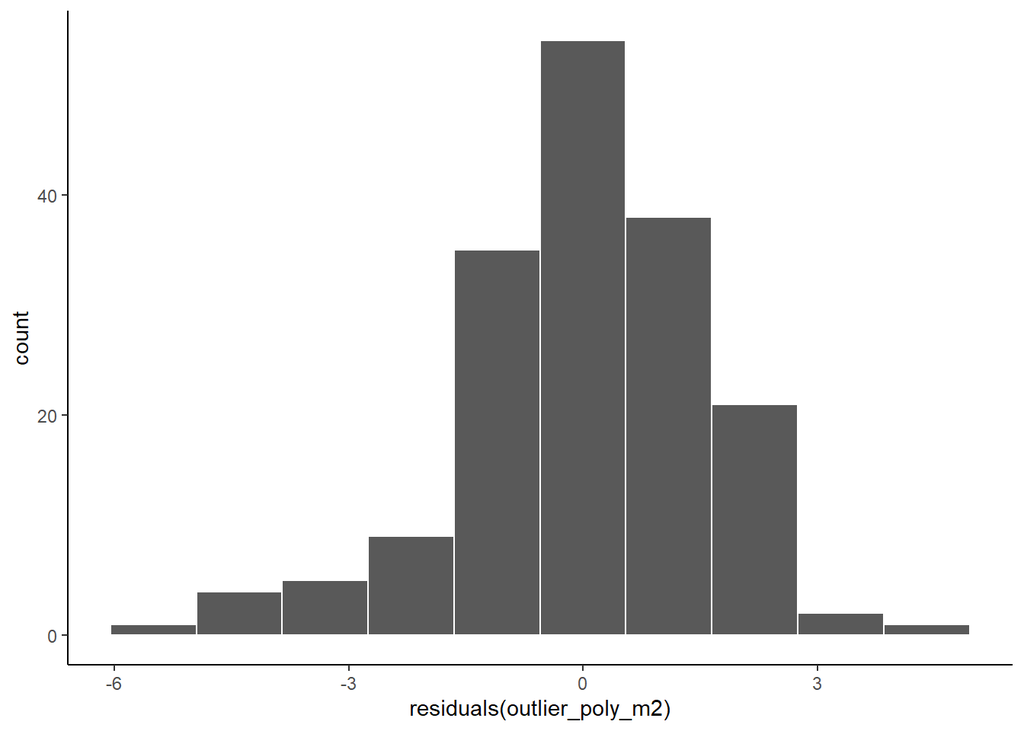

```r
#histogram of residuals
ggplot(data = life_outlier, aes(residuals(outlier_poly_m2))) +
  geom_histogram(col = "white", bins = 10) +
  theme_classic()
```

#### QQ-plot

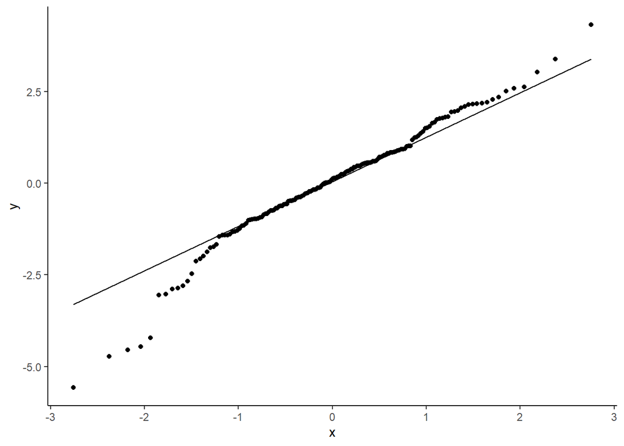

```r
#QQ-plot of residuals
ggplot(data = life_outlier, aes(sample = outlier_poly_m2$residuals)) +
    geom_qq() +
    stat_qq_line() +
    theme_classic()
```

#### Shapiro-Wilk’s test

```r
#Shapiro-Wilks test
shapiro.test(residuals(outlier_poly_m2))
```

```
##
##  Shapiro-Wilk normality test
##
## data:  residuals(outlier_poly_m2)
## W = 0.96732, p-value = 0.0004951
```

The Shapiro-Wilk’s test has rejected the null hypothesis in favor of the alternative, which is *life_expectancy* is non-normal. However, this test is powerful with n = 171 observations so any small deviation from normality will result in a significant p-value. The histogram of residuals appears Gaussian and the QQ-plot is linear. Therefore, the assumption of normality is met.

### Homoscedasticity

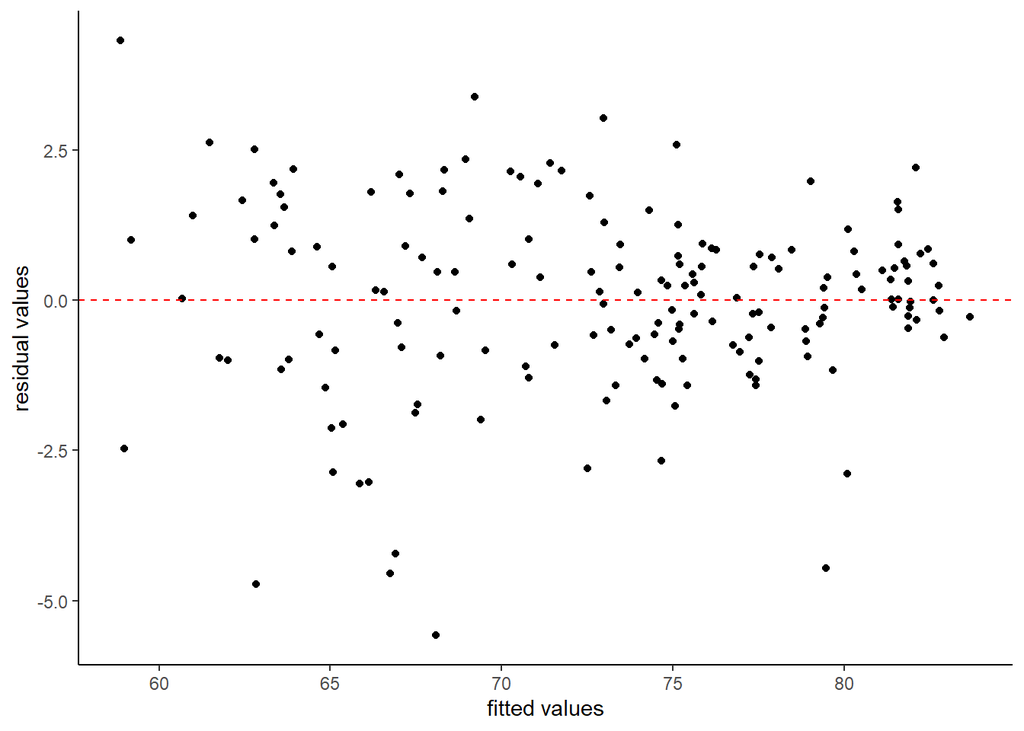

```r
#residual vs fitted plot
ggplot(data = outlier_poly_m2, aes(x = .fitted, y = .resid)) +
  geom_point() +
  geom_hline(yintercept = 0, col = "red", linetype = "dashed") +
  labs(x = "fitted values", y = "residual values") +
  theme_classic()
```

```r
#Breusch-Pagan test of equal variance
bptest(outlier_poly_m2)
```

```
##
##  studentized Breusch-Pagan test
##
## data:  outlier_poly_m2
## BP = 23.396, df = 9, p-value = 0.005366
```

The Breusch-Pagan test rejects the null hypothesis in favor of the alternative that the residuals are heteroscedastic. However, this test suffers from the same limitation as the Shapiro-Wilk’s test, high power with large sample sizes. The residual vs fitted plot shows no obvious patterns or funneling indicating equal variance across fitted values. Therefore, the assumption of homoscedasticity is met.

### Linearity

```r
#define variables
y_var = "life_expectancy"
x_var = c("traffic_mortality","prob_of_death_by_CVD_cancer_diabetes_CRD","maternal_mortality","adult_hypertension","TB","doctor_density")

#create plots
plots = list()
for(i in 1:length(x_var)){
  plot = ggplot(data = life, aes_string(y = y_var, x = x_var[i])) +
    geom_point(size = 2) +
    theme_classic()

  plots[[i]] = plot
}
```

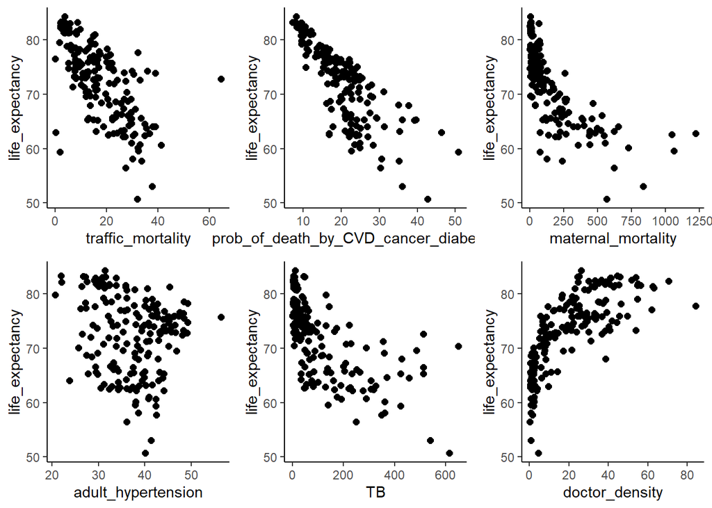

```r
#visualize plots
grid.arrange(grobs = plots, ncol = 3)
```

Most independent variables appear linear with *life_expectancy*. The independent variables that don’t appear linear have second order polynomial terms to correct for this. Additionally, the residual vs fitted plot above is straight with no obvious patterns or curves. Therefore, the assumption of linearity is met.

### Independence

The residual vs fitted plot above shows no patterns or evidence of dependence between residuals. It is also assumed that all observations were taken independently from one another. Therefore, the assumption of independence is met.

## Final model

```r
final_model = outlier_poly_m2
summary(final_model)
```

```
##
## Call:
## lm(formula = life_expectancy ~ traffic_mortality + prob_of_death_by_CVD_cancer_diabetes_CRD +
##     maternal_mortality + I(maternal_mortality^2) + adult_hypertension +
##     TB + doctor_density + I(doctor_density^2) + traffic_mortality *
##     TB, data = life_outlier)
##
## Residuals:
##     Min      1Q  Median      3Q     Max
## -5.5803 -0.7787  0.1075  0.8610  4.3195
##
## Coefficients:
##                                            Estimate Std. Error t value Pr(>|t|)
## (Intercept)                               8.485e+01  9.463e-01  89.663  < 2e-16
## traffic_mortality                        -4.519e-02  2.337e-02  -1.934 0.054857
## prob_of_death_by_CVD_cancer_diabetes_CRD -4.171e-01  2.555e-02 -16.327  < 2e-16
## maternal_mortality                       -1.832e-02  2.465e-03  -7.432 6.08e-12
## I(maternal_mortality^2)                   9.994e-06  2.337e-06   4.277 3.24e-05
## adult_hypertension                       -7.112e-02  2.121e-02  -3.353 0.000999
## TB                                        3.441e-03  3.307e-03   1.041 0.299661
## doctor_density                            1.679e-01  3.543e-02   4.738 4.72e-06
## I(doctor_density^2)                      -1.805e-03  5.145e-04  -3.509 0.000584
## traffic_mortality:TB                     -4.033e-04  1.366e-04  -2.952 0.003629
##
## (Intercept)                              ***
## traffic_mortality                        .
## prob_of_death_by_CVD_cancer_diabetes_CRD ***
## maternal_mortality                       ***
## I(maternal_mortality^2)                  ***
## adult_hypertension                       ***
## TB
## doctor_density                           ***
## I(doctor_density^2)                      ***
## traffic_mortality:TB                     **
## ---
## Signif. codes:  0 '***' 0.001 '**' 0.01 '*' 0.05 '.' 0.1 ' ' 1
##
## Residual standard error: 1.587 on 160 degrees of freedom
##   (1 observation deleted due to missingness)
## Multiple R-squared:  0.9458, Adjusted R-squared:  0.9428
## F-statistic: 310.3 on 9 and 160 DF,  p-value: < 2.2e-16
```

## Model predictions

### Japan

```r
predict(final_model, newdata=data.frame(traffic_mortality=3.6, prob_of_death_by_CVD_cancer_diabetes_CRD=8.3, maternal_mortality=4, adult_hypertension=31.4, TB=11, doctor_density=26.1), interval="predict")
```

```
##        fit      lwr      upr
## 1 82.09228 78.89861 85.28594
```

Actual life expectancy = 84.3 years

### Kenya

```r
predict(final_model, newdata=data.frame(traffic_mortality=28.3, prob_of_death_by_CVD_cancer_diabetes_CRD=21, maternal_mortality=530, adult_hypertension=33.2, TB=251, doctor_density=2.3), interval="predict")
```

```
##        fit     lwr      upr
## 1 63.92506 60.7151 67.13502
```

Actual life expectancy = 66.1 years

### Central African Republic

```r
predict(final_model, newdata=data.frame(traffic_mortality=37.7, prob_of_death_by_CVD_cancer_diabetes_CRD=36, maternal_mortality=835, adult_hypertension=41.3, TB=540, doctor_density=0.7), interval="predict")
```

```
##        fit      lwr      upr
## 1 50.63047 46.83226 54.42868
```

Actual life expectancy = 53.1 years